# Team 5 EDA Final

# New York City

## Introduction to New York City

[figure not shown]

For the other cities we choose to the surrounding areas as it can be hard to break up the city itself into very distinct areas. However, New York city is a bit odd in this respect because it so easily is broken up into the five borrows. These five boroughs have unique characteristics that are represented similarly as suburban and other surrounding areas would be for other major metropolitan areas. As such, we decided to opt for looking at the education and economic opportunities exclusively within New York City. We believe that this better represents our motivating question because it would allow us to slice the data across distinct axis while still retaining the heart of where is the most opportunity.

## Livability in New York City

Life quality is in a city is an exceptionally hard thing to measure and will tend to vary from person to person. While quality of life might seem like an extraneous variable it is intimately linked to success even if it is not always in an obvious manner. Unfortunately, our study is focused more on the educational and economic indicators of success in a city. However, the data as mentioned is still exceptionally important so while not the main focus on the analysis it is still worth including if for no other reason than to paint a picture of the overall understanding of the boroughs in the city.

### Commutes and Walkability

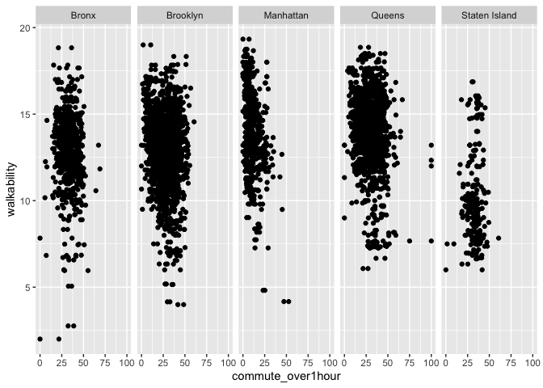

The first part of the analysis will link the walkability. As a general rule of thumb big cities tend to be more “walkable”. As such, it seems there should be a direct negative relationship between the commute_over1hour and the walkability of the city. It seems however that most of the boroughs in the city tend to be equally walkable and have similar percentages of commutes over an hour.

### Green Spaces and Pollution

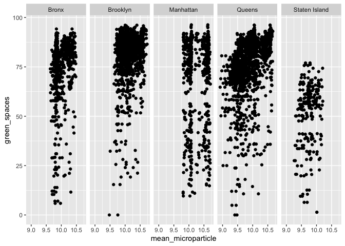

It does seem that there also a lack of relationship between the number of green spaces and the mean micro-particles i.e. pollution. The amount of pollution does seem to be fairly high in all of them expect Staten Island which consequently appears to exhibit the least amount of green spaces. However, it is worth mentioning that might be skewed for Manhattan due to Central Park.

### Neighborhood Population and Poverty

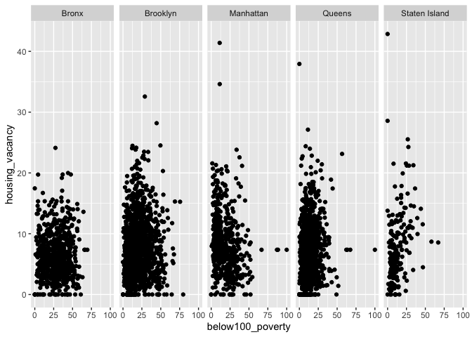

### Education Centers

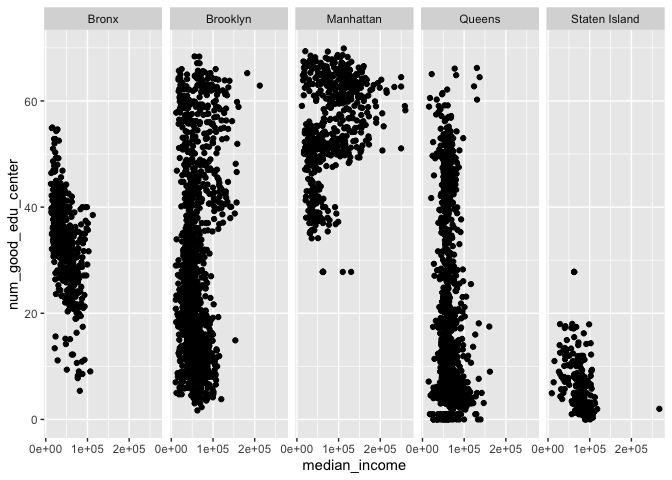

The last factor is a perfect sequeway to the topic of education. This graph is fairly inline also with what we would expect to see which is that as the income increases in the borough better education centers appear.

## Education Status in New York City

### Math and Reading in Elementary School Students

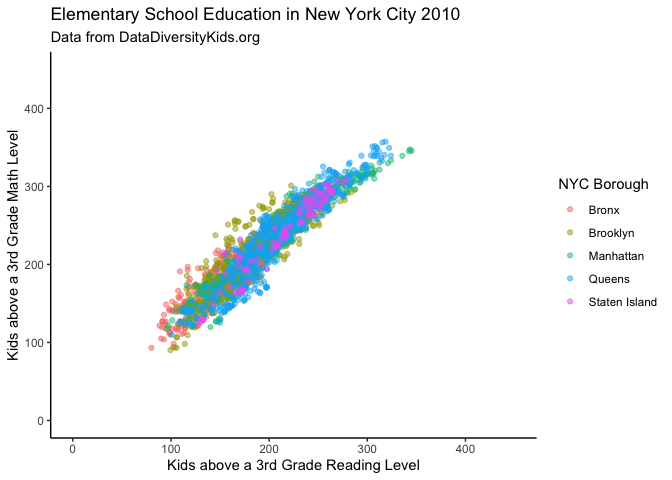

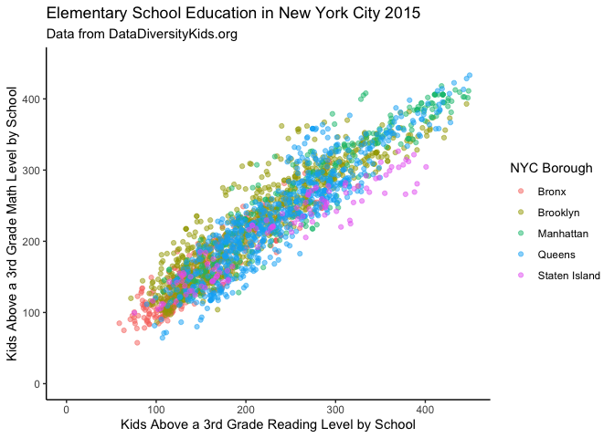

The first and most obvious indicator of education success is how well elementary students are doing in a given area. This obviously hinges on numerous factors such as teachers and income just for starters. However, first we will want to look at the trends and correlation between the two factors and across the two years given in our data set.

As expected, reading and math scores at the third grade level track in nearly lockstep across all boroughs. This makes sense because most of the students have not specialized like they will in college and the material at this level more tests cognitive ability than skills within that field(find citation). However, what is interesting is the dispersion of the data of exhibits a higher variance over time. Due to the amount of points it can be hard to see who did better, worse, or stayed the same.

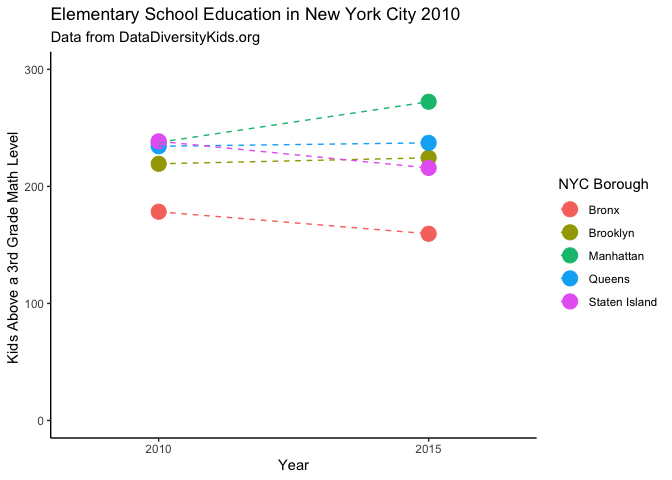

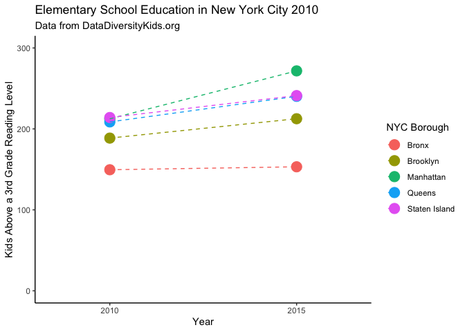

Moving forward we will compare Manhattan and the Bronx because of the stark differences it should be easier to find potentially patterns that *could* cause or represent these differences.

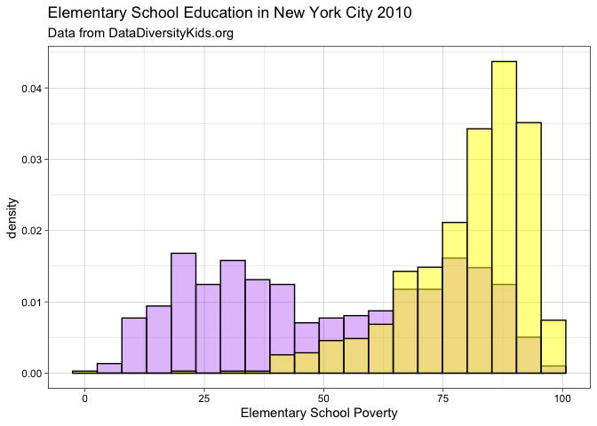

The first and most obvious one to check is the levels of poverty exhibited by the school. If Manhattan and the Bronx exhibit different levels of poverty especially significant ones it could be a leading cause in what causes the differences in math and reading ability. The graph above which plots the frequency of which schools are afflicted with poverty paints a clear picture that Manhattan has both less severe poverty and less frequent poverty. However, it is possible that this maybe has no affect on ability.

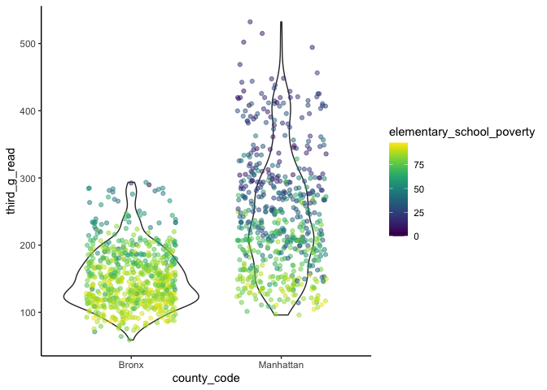

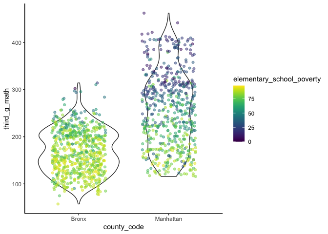

## Economic Variablity in New York City

### Median Income

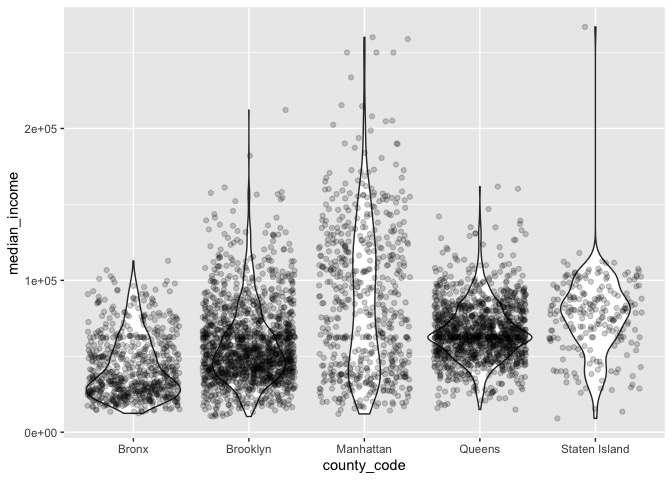

The first economic indicator of economic success seems pretty obvious - the amount of money made in terms of the median. The mean is avoided here to prevent extreme cases from driving up or down the amount. From the graph the first two that stick out are Manhattan and the Bronx for the opposite reasons. Manhattan seems to have more economic success and the Bronx seems to be struggling. As the financial center of the world it does not come as a surprise to Manhattans success. However, given the proximity of the Bronx to Manhattan the reason for the Bronx’s struggle is not as clear.

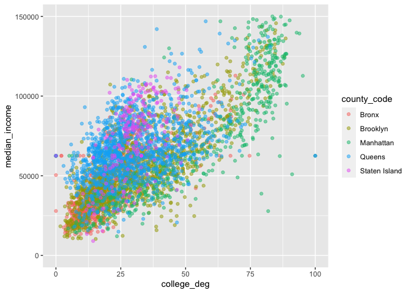

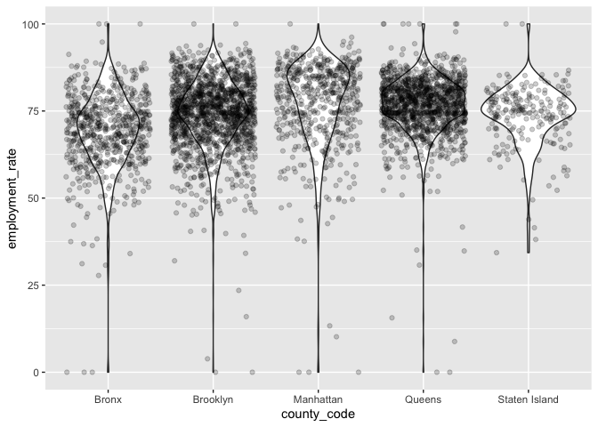

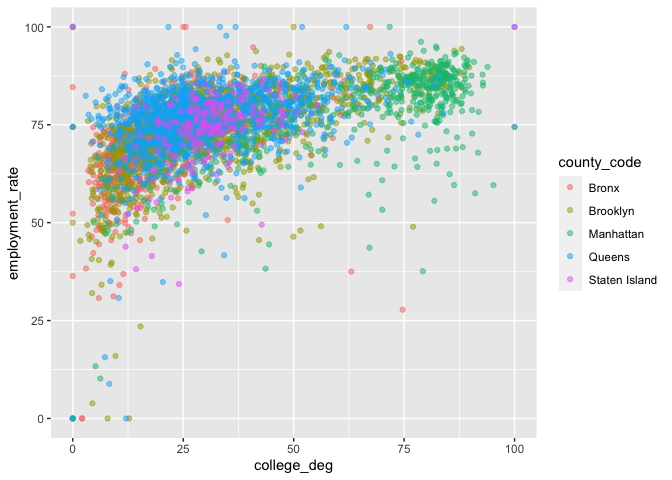

This is one of the most interesting graphs. It appears from this graph that the employment rate is nearly devoid of a relationship with a college degree expect in the extreme cases of a lack of degree. However, it is very possible that relationship is actually inverted with the employment generating whether someone has the opportunity to go to college instead of the other way around.

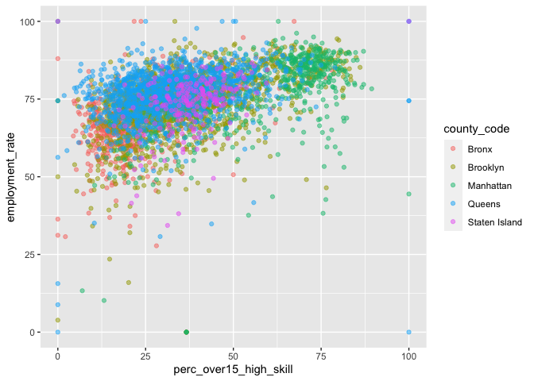

Given the relationship above it seems to make sense that perhaps is being a high skilled worked that drives employment rate. However, that also does not seem to be true expect again in the extreme case.

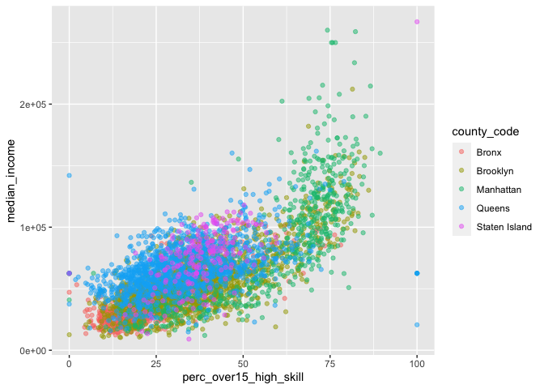

However, college degrees are not the sole measure for financial stability. There are numerous other factors like being high skilled worker which would include things like trade school. Here you do see a bit more of a relationship between high skill and median income though not one as stark as having a college degree.

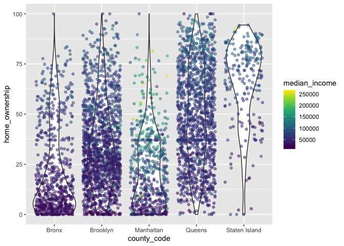

The last graph might seem like it belongs in livability which is an argument is fairly solid. However, given that often times a house seems to be the largest asset housing rates are also right at home in financial success. While one might expect Manhattan to have the largest amount of homes it is apparent this is not the case until you progress into the super wealthy. Given the price of real estate in the city this makes sense. The Bronx also matchs what you would expect as does Staten Island as real estate prices drop.